# R Stats Package Exercise

Jerri Schorr

11-19-2019

### Set Up

Stats is a base package, meaning it should already be installed, if it is not or if it needs updated, R will do so when you run `install.packages`.

- We will be using the “cars” data set in R for the following exercises

### Exercise 1

Let’s find the median of data.

- The median is used instead of the mean when the data has a very large spread of data

```r
median(cars$speed)
```

```
[1] 15
```

```r
median(cars$dist)
```

```
[1] 36
```

```r
#you can choose any column, variable, or data set you would like to put in the function
```

### Exercise 2

Now let’s find the standard deviation of data.

- Standard Deviation is a measure of spread.

```r
sd(cars$speed)
```

```
[1] 5.287644
```

```r
sd(cars$dist)
```

```
[1] 25.76938
```

```r
#you can choose any column, variable, or data set you would like to put in the function
```

### Exercise 3

Now let’s find the Inter Quartile Range (IQR) of data.

- The IQR tells you the distance between the 3rd quartile and the 1st quartile

```r
IQR(cars$speed)
```

```
[1] 7
```

```r
IQR(cars$dist)
```

```
[1] 30
```

```r
#you can choose any column, variable, or data set you would like to put in the function
```

### Exercise 4

Next we will fit the data with a Linear Model to see its relationship

- Linear Models show whether data is correlated in a positive direction, negative direction, or if there is no correlation.

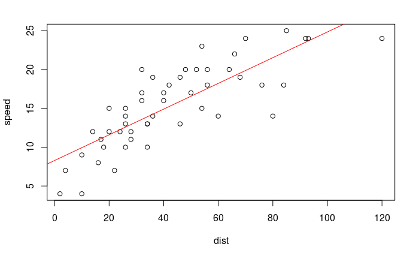

```r
dist <- cars$dist
speed <- cars$speed
plot(dist, speed)
fit1 <- lm(speed ~ dist, data = cars)
abline(fit1, col = "red")
```

```r
# be sure to highlight all code above and run all at once to plot the data and see the fir of the linear model
#you always want to put your response, or y, variable first in the lm function.
summary(fit1)# this will give you all of the details for the linear model
```

```
Call:
lm(formula = speed ~ dist, data = cars)

Residuals:
    Min      1Q  Median      3Q     Max
-7.5293 -2.1550  0.3615  2.4377  6.4179

Coefficients:
            Estimate Std. Error t value Pr(>|t|)
(Intercept)  8.28391    0.87438   9.474 1.44e-12 ***
dist         0.16557    0.01749   9.464 1.49e-12 ***
---
Signif. codes:  0 ‘***’ 0.001 ‘**’ 0.01 ‘*’ 0.05 ‘.’ 0.1 ‘ ’ 1

Residual standard error: 3.156 on 48 degrees of freedom
Multiple R-squared:  0.6511,    Adjusted R-squared:  0.6438
F-statistic: 89.57 on 1 and 48 DF,  p-value: 1.49e-12
```

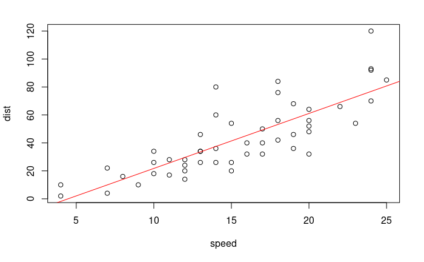

```r
plot(speed, dist)
fit2 <- lm(dist ~ speed, data = cars)
abline(fit2, col = "red")
```

```r
summary(fit2)
```

```
Call:
lm(formula = dist ~ speed, data = cars)

Residuals:
    Min      1Q  Median      3Q     Max
-29.069  -9.525  -2.272   9.215  43.201

Coefficients:
            Estimate Std. Error t value Pr(>|t|)
(Intercept) -17.5791     6.7584  -2.601   0.0123 *
speed         3.9324     0.4155   9.464 1.49e-12 ***
---
Signif. codes:  0 ‘***’ 0.001 ‘**’ 0.01 ‘*’ 0.05 ‘.’ 0.1 ‘ ’ 1

Residual standard error: 15.38 on 48 degrees of freedom
Multiple R-squared:  0.6511,    Adjusted R-squared:  0.6438
F-statistic: 89.57 on 1 and 48 DF,  p-value: 1.49e-12
```